# NHANES reproduction bioage collaboration

Talia Shirazi, Calen Ryan, Waylon Hastings et al

October 23, 2019

## Welcome!

This is the initial report (10.24.2019) for the NHANES reproduction bioage project, largely based on papers by two smart people on [costs of reproduction](https://www.nature.com/articles/s41598-018-29486-4) and on [biological aging measures in NHANES](https://www.ncbi.nlm.nih.gov/pubmed/30999227). Feedback is highly encouraged. I’m excited about this project, and if you’re reading this, I hope you are too.

Before we get started, a quick note about the different aging measures we’ll see. For all except for telomere length, higher = associated with older age, and lower = associated with younger age; for telomere length, we’d expect the opposite.

Homeostatic Dysregulation (HD) and the Klemera-Doubal Method (KDM) utilize the same 12 markers, though the underlying math differs. The markers are as follows: albumin, alkaline phosphatase, blood urea nitrogen, creatinine, C-reactive protein, glycated hemoglobin, uric acid, white blood cell count, lymphocyte percent, mean corpuscular volume, red cell distribution width, and systolic blood pressure.

The Levine Method (LM) has some overlap with the methods above, but utilizes the following 9 markers: albumin, alkaline phosphatase, creatinine, c-reactive protein, glucose, white blood cell count, lymphocyte percent, mean corpuscular volume, and red cell distribution width.

As for Telomere Length, you already know. Now that we have a better understanding of these measures, let’s get to it!

Load the 8 million packages we’ll need.

```r
library(RNHANES)
library(haven)
library(psych)
library(dplyr)
library(ggplot2)
library(survey)
library(factoextra)
library(jtools)
library(ggstance)
library(corrplot)
library(GGally)
library(stargazer)
```

In this step, we’ll load the necessary NHANES data frames, recode, and do some general wrangling so that datasets can be combined and analyzed.

```r
demo1 <- nhanes_load_data("DEMO", "1999-2000", demographics = FALSE)
demo2 <- nhanes_load_data("DEMO_B", "2001-2002", demographics = FALSE)

demo1 <- demo1[,c("SEQN", "SDMVPSU", "SDMVSTRA")]
demo2 <- demo2[,c("SEQN", "SDMVPSU", "SDMVSTRA")]
DEMO <- rbind(demo1,demo2)

#### Import smoking aq's

smq1 <- nhanes_load_data("SMQ", "1999-2000", demographics = FALSE)
smq2 <- nhanes_load_data("SMQ_B", "2001-2002", demographics = FALSE)

smq1_short<-smq1[c("SMQ020", "SMQ040", "SEQN")]
smq2_short<-smq2[c("SMQ020", "SMQ040", "SEQN")]
#SMQ020 Smoked 100 cigarettes in life? 1 = yes 2 = no
#SMQ040 DO you now smoke cigarettes? 1 = every day, 2 = some days, 3 = not at all

SMQ<- rbind(smq1_short,smq2_short)

SMQ <- na_if(SMQ, 7)
SMQ <- na_if(SMQ, 9)

SMQ$smoking <- 2 #current smoker
SMQ$smoking[SMQ$SMQ020==2]<-0 #never smoker
SMQ$smoking[SMQ$SMQ040==3]<-1 #past smoker

#remove one person with no SEQN
SMQ <- SMQ[which(SMQ$SEQN>0),]

#### RHQ

rhq1 <- nhanes_load_data("RHQ", "1999-2000", demographics = FALSE)
rhq2 <- nhanes_load_data("RHQ_B", "2001-2002", demographics = FALSE)

rhq1_short<- rhq1[c("SEQN", "RHD130", "RHQ140", "RHQ150", "RHQ160", "RHD170", "RHQ180", "RHQ190", "RHQ200", "RHQ210", "RHD230")]
#RHD130 Ever been pregnant? 1 = yes, 2= no
#RHQ140 Think you are pregnant now? 1 = yes, 9 = don't know
#RHQ150 What month of pregnancy are you in? 1-10 = range of values, 99 = don't know
#RHQ160 How many times have you been pregnant? 1-55 = range of values, 77 = refused, 99 = don't know
#RHD170 Number of pregnancies resulting in live births 1-10 = range of values, 11 = 11 or more, 77 = refused
#RHQ180 Age of first live birth 13-41 = range of values, 999= don't know
#RHQ190 Age at last live birth 11-57 = range of values, 999 = don't know
#RHQ200 Now breastfeeding a child? 1 = yes, 2 = no
#RHQ210 breastfed any of your children? 1 = yes, 2 = no
#RHD230 Number of children breastfed at least 1 month 0-13 = range of values

rhq2_short<- rhq2[c("SEQN", "RHD130", "RHQ141", "RHQ151", "RHQ160", "RHD170", "RHQ180", "RHQ190", "RHQ200", "RHQ210", "RHD230")]
#RHD130 Ever been pregnant? 1 = yes, 2= no, 9 = don't know
#RHQ141 Think you are pregnant now? 1 = yes, 9 = don't know
#RHQ151 What month of pregnancy are you in? 1-9 = range of values, 99 = don't know
#RHQ160 How many times have you been pregnant? 1-18 = range of values, 77 = refused, 99 = don't know
#RHD170 Number of pregnancies resulting in live births 1-10 = range of values, 11 = 11 or more, 77 = refused
#RHQ180 Age of first live birth 12-39 = range of values, 999= don't know
#RHQ190 Age at last live birth 13-57 = range of values, 999 = don't know
#RHQ200 Now breastfeeding a child? 1 = yes, 2 = no
#RHQ210 breastfed any of your children? 1 = yes, 2 = no, don't know = 9
#RHD230 Number of children breastfed at least 1 month 0-13 = range of values, 99 = don't know

#Change column names so can rbind
colnames(rhq2_short)[3:4] <- c("RHQ140","RHQ150")

#Combine cycles
RHQ<- rbind(rhq1_short,rhq2_short)

#Change column names so they don't suck
colnames(RHQ)[2:11] <- c("everpreg", "currentpreg", "currentpregmonth", "timespreg", "livebirths", "firstlivebirth", "lastlivebirth", "currentbreastfeed", "everbreastfed", "numberbreastfed")

#Recode the 'refused' and 'don't know's in RHQ data as NA (values differ by variable)
RHQ <- na_if(RHQ, 999)
RHQ <- na_if(RHQ, 77)
RHQ <- na_if(RHQ, 99)
RHQ$everpreg <- na_if(RHQ$everpreg, 9)
RHQ$everbreastfed <- na_if(RHQ$everbreastfed, 9)

RHQSMQ <- merge(RHQ, SMQ, by = "SEQN", all = TRUE)
NHANES <- merge(RHQSMQ, DEMO, by = "SEQN", all = TRUE)
```

Brief sanity check that the ‘number of live births’ and ‘ever pregnant’ variables were recoded correctly.

```r
table(NHANES$livebirths, NHANES$everpreg)
```

```
##
##         1    2
##   0   249    0
##   1   897    0
##   2  1070    0
##   3   853    0
##   4   432    0
##   5   255    0
##   6   149    0
##   7    92    0
##   8    49    0
##   9    29    0
##   10   32    0
##   11   45    0
```

Now we transform the live births variable because it is visibly skewed. We’ll add 1 and then log-transform. We’ll also square that and create a new term, livebirths2, so we can test for quadratic effects. In this step we’ll also transform the variable indexing whether a woman has ever been pregnant so that 0 = never pregnant, and 1 = ever pregnant.

```r
NHANES$livebirths<-(log(NHANES$livebirths+1))
NHANES$livebirths2 <- NHANES$livebirths^2
NHANES$everpreg[NHANES$everpreg==2]<-0
```

We’ll now import the bioage measure dataset, do some recoding, combine it with the NHANES dataset we obtained above, and de-clutter.

```r
NHANES_BA_Talia <- read_sav("C:/Users/talia/Box Sync/NHANES/Biological aging reproduction project/NHANES_BA_Talia.sav")
colnames(NHANES_BA_Talia)[1] <- "SEQN"

#Combine all data
df <- merge(NHANES,NHANES_BA_Talia,by="SEQN")

#Declutter
rm(NHANES_BA_Talia, RHQ, rhq1, rhq1_short, rhq2, rhq2_short, smq1, smq1_short, smq2, smq2_short, SMQ)
```

Better. Now we’ll specify the survey design – this takes into account things like sample weights, which allow us to extrapolate our data beyond our sample and calculate population-based estimates.

```r
base <- svydesign(id      = ~SDMVPSU,
                          strata  = ~SDMVSTRA,
                          weights = ~WTMEC4YR,
                          nest    = TRUE,
                          data    = df)
```

Survey design specification part two: our subsample. We now indicate that we want to look at a specific subpopulation of all NHANES 1999-2002 data: women between 18 and 50 who aren’t currently pregnant, and who have nonmissing data for number of live births.

```r
nhanesDesign<- subset(base, age >17 & age < 51 & pregnant !=1 & livebirths>-1)
```

Alright now the fun stuff – real stats! First we’ll build models looking at each biological aging measure and number of live births alone (no covariates), just for kicks. These models include both a linear term and quadratic term for number of live births.

Note that we’ll be hiding the model outputs for now, and will be visualizing them after all the models have been specified.

```r
summary(a1 <- svyglm(HD ~ livebirths + livebirths2, design = nhanesDesign))
summary(a2 <- svyglm(LM ~ livebirths + livebirths2, design = nhanesDesign))
summary(a3 <- svyglm(KDM ~ livebirths + livebirths2, design = nhanesDesign))
summary(a4 <- svyglm(log_telo ~ livebirths + livebirths2, design = nhanesDesign))
```

Because these biological aging measures are correlated with chronological age, we’ll repeat what we did above, this time including chronological age.

```r
summary(b1 <- svyglm(HD ~ livebirths + livebirths2 + age, design = nhanesDesign))
summary(b2 <- svyglm(LM ~ livebirths + livebirths2 + age, design = nhanesDesign))
summary(b3 <- svyglm(KDM ~ livebirths + livebirths2 + age, design = nhanesDesign))
summary(b4 <- svyglm(log_telo ~ livebirths + livebirths2 + age, design = nhanesDesign))
```

There are obviously other things that affect biological aging; some examples that have been controlled for in past work on [reproduction and telomere length in NHANES](https://academic.oup.com/humrep/article/33/4/736/4858327) are smoking status and BMI. We’ll control for them in the models below.

```r
summary(c1 <- svyglm(HD ~ livebirths + livebirths2 + age + bmi + smoking, design = nhanesDesign))
summary(c2 <- svyglm(LM ~ livebirths + livebirths2 + age + bmi + smoking, design = nhanesDesign))
summary(c3 <- svyglm(KDM ~ livebirths + livebirths2 + age + bmi + smoking, design = nhanesDesign))
summary(c4 <- svyglm(log_telo ~ livebirths + livebirths2 + age + bmi + smoking, design = nhanesDesign))
```

There are yet MORE things that we could control for. In the models below, we’ll also control for education, income, food security, and self-reported ethnicity (in addition to chronological age, BMI, and smoking status).

```r
summary(d1 <- svyglm(HD ~ livebirths + livebirths2 + age + bmi + smoking + education + poverty + ridreth1 + food_security, design = nhanesDesign))
summary(d2 <- svyglm(LM ~ livebirths + livebirths2 + age + bmi + smoking + education + poverty + ridreth1 + food_security, design = nhanesDesign))
summary(d3 <- svyglm(KDM ~ livebirths + livebirths2 + age + bmi + smoking + education + poverty + ridreth1 + food_security, design = nhanesDesign))
summary(d4 <- svyglm(log_telo ~ livebirths + livebirths2 + age + bmi + smoking + education + poverty + ridreth1 + food_security, design = nhanesDesign))
```

If we’re interested in testing whether the relationship between number of live births and biological aging differs based on resource availibility (oh hey, we indeed are!), we need to create a composite of ‘resource availibility’ based on the measures we’ve got. Keep in mind that this is a rough, likely noisy proxy for true ‘resource availibility.’

```r
#First, need to select complete cases
df2<- df %>%
  filter(complete.cases(education, poverty, food_security))

pca<-prcomp(df2[,c("education", "poverty", "food_security")], scale=TRUE)
pca_values<-get_pca_ind(pca)
pca_values<-as.data.frame(pca_values$coord)
df2<-cbind(df2,pca_values)

#Median split for Dim.1
df2$Dimmediansplit<- 1 # high resource availibility
df2$Dimmediansplit[df2$Dim.1>-0.01] <- 0 # low resource availibility

#Select columns of interest in df2
df2<-df2[,c("SEQN", "Dim.1", "Dimmediansplit")]

#Merge with df
df <- merge(df,df2, by="SEQN", all = TRUE)
```

Now we redefine survey parametersfor this new dataset.

```r
base <- svydesign(id      = ~SDMVPSU,
                          strata  = ~SDMVSTRA,
                          weights = ~WTMEC4YR,
                          nest    = TRUE,
                          data    = df)

nhanesDesign<- subset(base, age >17 & age < 51 & pregnant !=1 & livebirths>-1)
nhanesDesign2<- subset(base, age >17 & age < 51 & pregnant !=1 & livebirths>-1 & Dimmediansplit == 0)
nhanesDesign3<- subset(base, age >17 & age < 51 & pregnant !=1 & livebirths>-1 & Dimmediansplit == 1)
```

Run models, run!

```r
summary(e1 <- svyglm(HD ~ livebirths*Dim.1 + livebirths2*Dim.1 + age + bmi + smoking + ridreth1, design = nhanesDesign))
```

```
##
## Call:
## svyglm(formula = HD ~ livebirths * Dim.1 + livebirths2 * Dim.1 +
##     age + bmi + smoking + ridreth1, design = nhanesDesign)
##
## Survey design:
## subset(base, age > 17 & age < 51 & pregnant != 1 & livebirths >
##     -1)
##
## Coefficients:
##                    Estimate Std. Error t value Pr(>|t|)
## (Intercept)        1.809475   0.124043  14.588 4.02e-12 ***
## livebirths        -0.289264   0.124753  -2.319   0.0311 *
## Dim.1              0.115439   0.044317   2.605   0.0169 *
## livebirths2        0.115754   0.070549   1.641   0.1165
## age                0.022024   0.002568   8.578 3.90e-08 ***
## bmi                0.020416   0.002578   7.919 1.36e-07 ***
## smoking            0.048129   0.027210   1.769   0.0922 .
## ridreth1           0.016718   0.019302   0.866   0.3967
## livebirths:Dim.1  -0.070160   0.075951  -0.924   0.3666
## Dim.1:livebirths2  0.020395   0.040448   0.504   0.6196
## ---
## Signif. codes:  0 '***' 0.001 '**' 0.01 '*' 0.05 '.' 0.1 ' ' 1
##
## (Dispersion parameter for gaussian family taken to be 0.3946779)
##
## Number of Fisher Scoring iterations: 2
```

```r
summary(e2 <- svyglm(LM ~ livebirths*Dim.1 + livebirths2*Dim.1 + age + bmi + smoking + ridreth1, design = nhanesDesign))
```

```
##
## Call:
## svyglm(formula = LM ~ livebirths * Dim.1 + livebirths2 * Dim.1 +
##     age + bmi + smoking + ridreth1, design = nhanesDesign)
##
## Survey design:
## subset(base, age > 17 & age < 51 & pregnant != 1 & livebirths >
##     -1)
##
## Coefficients:
##                     Estimate Std. Error t value Pr(>|t|)
## (Intercept)       -15.035925   1.246345 -12.064 1.24e-10 ***
## livebirths         -3.301101   1.698922  -1.943 0.066219 .
## Dim.1               0.902911   0.546398   1.652 0.114051
## livebirths2         1.489695   0.817720   1.822 0.083482 .
## age                 1.007667   0.020971  48.051  < 2e-16 ***
## bmi                 0.274521   0.020964  13.095 2.86e-11 ***
## smoking             0.813444   0.203538   3.997 0.000709 ***
## ridreth1            0.006667   0.133800   0.050 0.960756
## livebirths:Dim.1    0.472969   0.950379   0.498 0.624149
## Dim.1:livebirths2  -0.514219   0.434831  -1.183 0.250848
## ---
## Signif. codes:  0 '***' 0.001 '**' 0.01 '*' 0.05 '.' 0.1 ' ' 1
##
## (Dispersion parameter for gaussian family taken to be 29.3229)
##
## Number of Fisher Scoring iterations: 2
```

```r
summary(e3 <- svyglm(KDM ~ livebirths*Dim.1 + livebirths2*Dim.1 + age + bmi + smoking + ridreth1, design = nhanesDesign))
```

```
##
## Call:
## svyglm(formula = KDM ~ livebirths * Dim.1 + livebirths2 * Dim.1 +
##     age + bmi + smoking + ridreth1, design = nhanesDesign)
##
## Survey design:
## subset(base, age > 17 & age < 51 & pregnant != 1 & livebirths >
##     -1)
##
## Coefficients:
##                   Estimate Std. Error t value Pr(>|t|)
## (Intercept)       -1.12743    1.14313  -0.986 0.335785
## livebirths        -3.40285    0.98931  -3.440 0.002593 **
## Dim.1              1.61598    0.40153   4.025 0.000664 ***
## livebirths2        0.56416    0.50121   1.126 0.273661
## age                0.81517    0.03055  26.681  < 2e-16 ***
## bmi                0.38384    0.02683  14.305 5.75e-12 ***
## smoking            0.16793    0.25961   0.647 0.525098
## ridreth1           0.04697    0.20997   0.224 0.825268
## livebirths:Dim.1  -2.09364    0.71340  -2.935 0.008193 **
## Dim.1:livebirths2  0.73821    0.35833   2.060 0.052636 .
## ---
## Signif. codes:  0 '***' 0.001 '**' 0.01 '*' 0.05 '.' 0.1 ' ' 1
##
## (Dispersion parameter for gaussian family taken to be 35.67363)
##
## Number of Fisher Scoring iterations: 2
```

```r
summary(e4 <- svyglm(log_telo ~ livebirths*Dim.1 + livebirths2*Dim.1 + age + bmi + smoking + ridreth1, design = nhanesDesign))
```

```
##
## Call:
## svyglm(formula = log_telo ~ livebirths * Dim.1 + livebirths2 *
##     Dim.1 + age + bmi + smoking + ridreth1, design = nhanesDesign)
##
## Survey design:
## subset(base, age > 17 & age < 51 & pregnant != 1 & livebirths >
##     -1)
##
## Coefficients:
##                     Estimate Std. Error t value Pr(>|t|)
## (Intercept)        0.1537764  0.0291947   5.267 3.73e-05 ***
## livebirths        -0.0266756  0.0343422  -0.777  0.44639
## Dim.1              0.0073964  0.0076579   0.966  0.34565
## livebirths2        0.0142133  0.0156265   0.910  0.37389
## age               -0.0020170  0.0006567  -3.071  0.00602 **
## bmi               -0.0015472  0.0006199  -2.496  0.02143 *
## smoking            0.0001657  0.0047004   0.035  0.97223
## ridreth1           0.0058412  0.0045124   1.294  0.21025
## livebirths:Dim.1  -0.0193093  0.0173404  -1.114  0.27868
## Dim.1:livebirths2  0.0072926  0.0085593   0.852  0.40429
## ---
## Signif. codes:  0 '***' 0.001 '**' 0.01 '*' 0.05 '.' 0.1 ' ' 1
##
## (Dispersion parameter for gaussian family taken to be 0.01037304)
##
## Number of Fisher Scoring iterations: 2
```

There is a significant Dim.1 (i.e., our composite measuring ‘resource availibility’) x live births interaction when predicting KDM. Let’s dig deeper into that by running those same models separately for women with lower and higher resource availibility, in that order.

```r
summary(e2.1 <- svyglm(KDM ~ livebirths + livebirths2 + age + bmi + smoking + ridreth1, design = nhanesDesign2))
```

```
##
## Call:
## svyglm(formula = KDM ~ livebirths + livebirths2 + age + bmi +
##     smoking + ridreth1, design = nhanesDesign2)
##
## Survey design:
## subset(base, age > 17 & age < 51 & pregnant != 1 & livebirths >
##     -1 & Dimmediansplit == 0)
##
## Coefficients:
##             Estimate Std. Error t value Pr(>|t|)
## (Intercept)  1.42528    1.02534   1.390  0.17782
## livebirths  -5.60827    1.76021  -3.186  0.00411 **
## livebirths2  1.18985    0.79956   1.488  0.15030
## age          0.86517    0.03243  26.678  < 2e-16 ***
## bmi          0.31454    0.03427   9.178 3.76e-09 ***
## smoking      0.03558    0.30289   0.117  0.90751
## ridreth1    -0.40023    0.26213  -1.527  0.14044
## ---
## Signif. codes:  0 '***' 0.001 '**' 0.01 '*' 0.05 '.' 0.1 ' ' 1
##
## (Dispersion parameter for gaussian family taken to be 33.73803)
##
## Number of Fisher Scoring iterations: 2
```

```r
summary(e2.2 <- svyglm(KDM ~ livebirths + livebirths2 + age + bmi + smoking + ridreth1, design = nhanesDesign3))
```

```
##
## Call:
## svyglm(formula = KDM ~ livebirths + livebirths2 + age + bmi +
##     smoking + ridreth1, design = nhanesDesign3)
##
## Survey design:
## subset(base, age > 17 & age < 51 & pregnant != 1 & livebirths >
##     -1 & Dimmediansplit == 1)
##
## Coefficients:
##             Estimate Std. Error t value Pr(>|t|)
## (Intercept) -4.13145    1.38204  -2.989  0.00655 **
## livebirths   0.25016    1.39106   0.180  0.85886
## livebirths2 -0.44651    0.61593  -0.725  0.47580
## age          0.78147    0.04058  19.259 1.10e-15 ***
## bmi          0.42472    0.03332  12.745 6.58e-12 ***
## smoking      0.24493    0.34866   0.702  0.48943
## ridreth1     0.30883    0.26524   1.164  0.25623
## ---
## Signif. codes:  0 '***' 0.001 '**' 0.01 '*' 0.05 '.' 0.1 ' ' 1
##
## (Dispersion parameter for gaussian family taken to be 33.96349)
##
## Number of Fisher Scoring iterations: 2
```

Potentially interesting, but potentially some weird spurious thing. What does it look like?

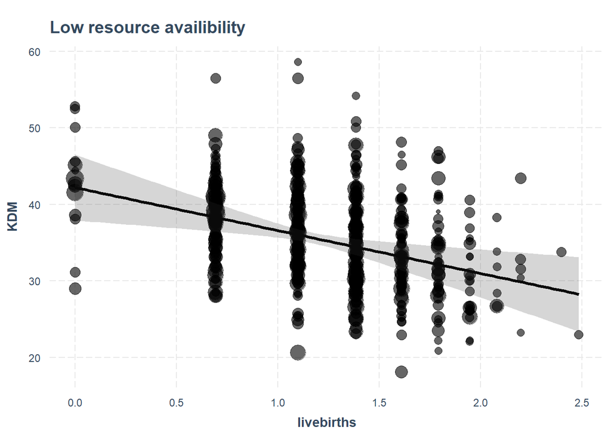

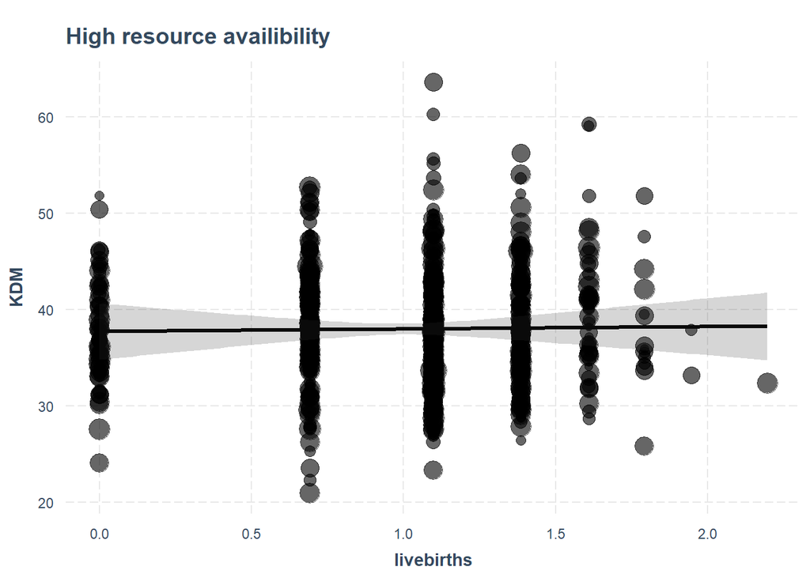

We’ll think about this more later…

In the meantime, let’s make some pretty pictures to summarize our above models. The visuals will describe models 1 through 5. Here’s what those mean:

- Model 1: No covariates. Remember that this model knowingly sucks and is just being included to demonstrate the effect of adding in covariates.
- Model 2: Age as covariate
- Model 3: Age, BMI, and smoking status as covariates
- Model 4: Age, BMI, smoking status, education, income, food security, and self-identified race/ethnicity as covariates
- Model 5: Age, BMI, smoking status, ethnicity, and the the composite of ‘resource availibility’ as covariates

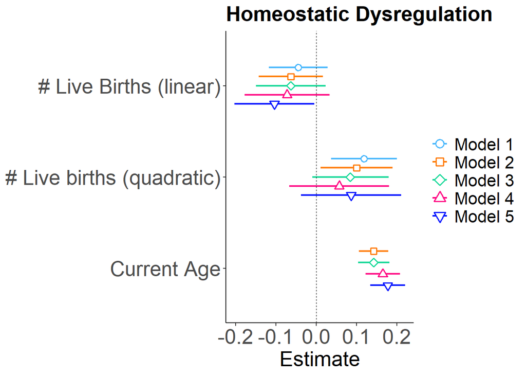

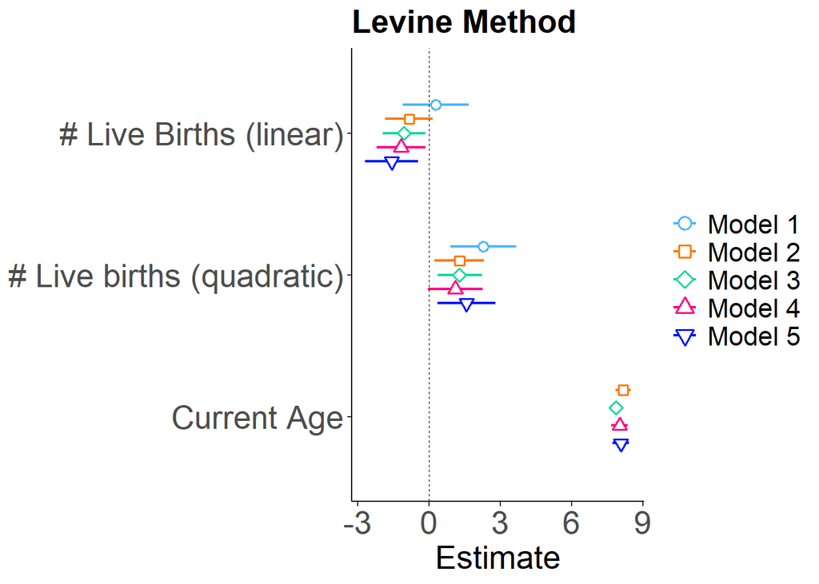

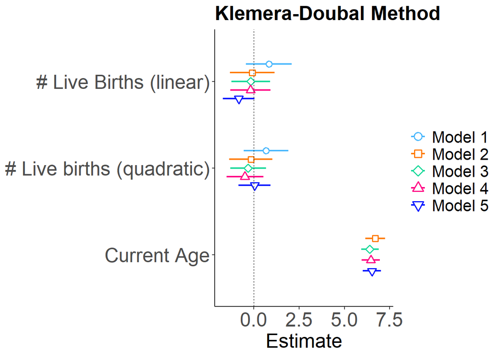

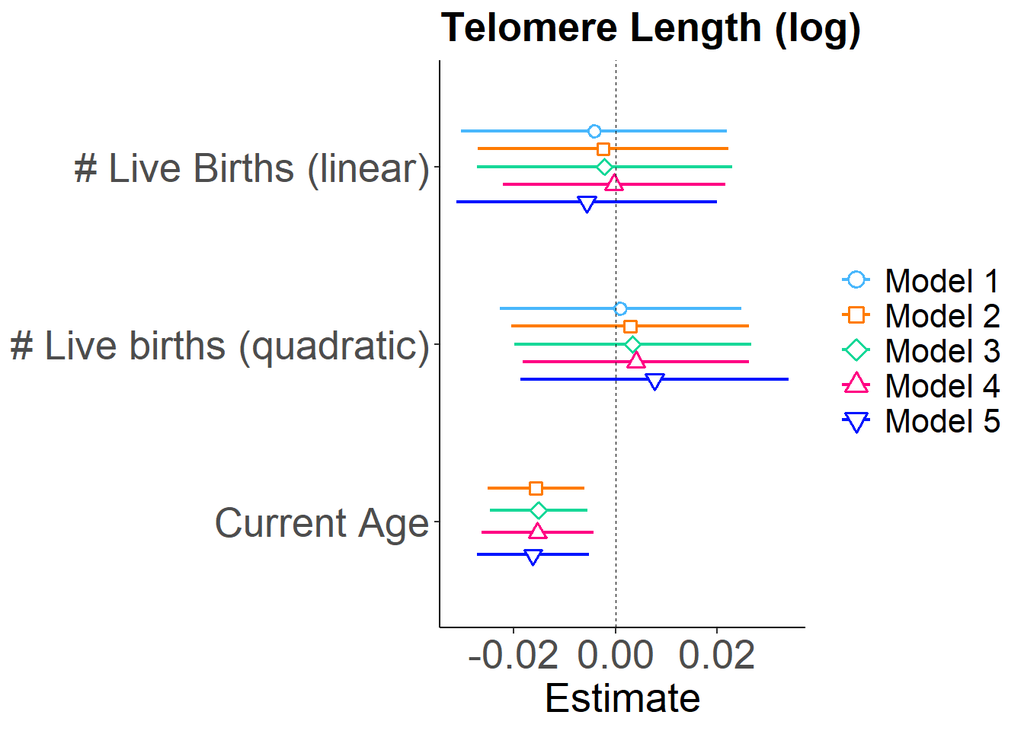

Let’s visualize this another way – using partial residual plots. These represent estimates from Model 5 (aka all covariates, ‘resource availibility’ composite).

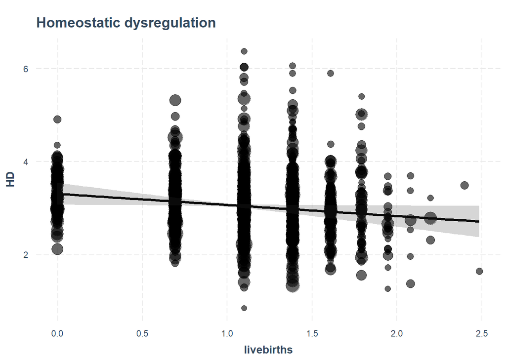

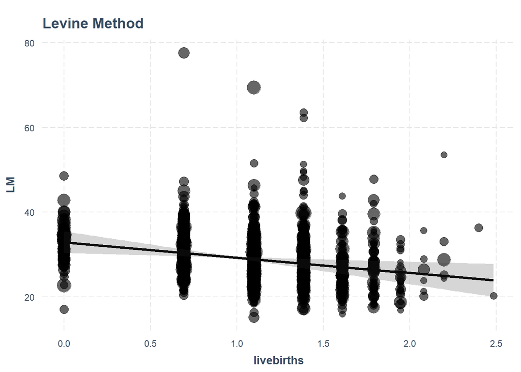

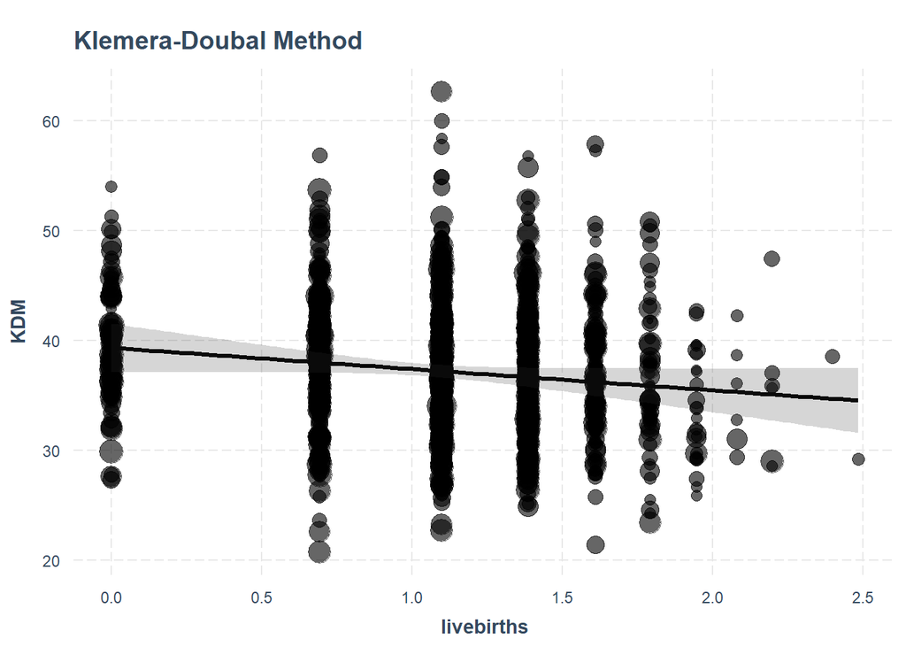

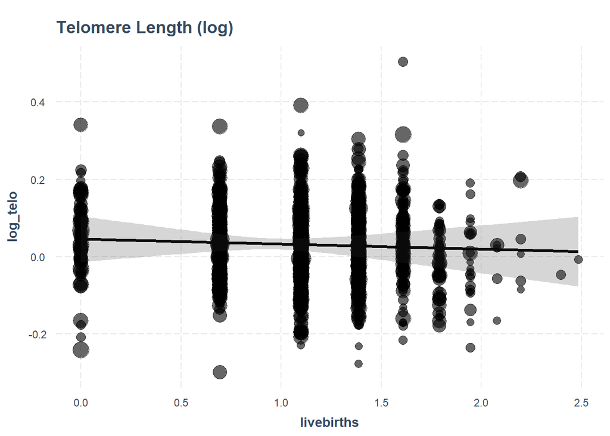

Maybe you’re more of a tables-and-charts kind of person, rather than a figures-and-graphs type of person. Don’t worry, I’ve got you covered. Here is a summary table of the results of models which include age, BMI, smoking status, ethnicity, and the the composite of ‘resource availibility’ as covariates (and obviously, number of live births).

|  | HD | LM | KDM | log_telo |
| --- | --- | --- | --- | --- |
|  | (1) | (2) | (3) | (4) |
| livebirths | -0.289* | -3.301<sup>+</sup> | -3.403** | -0.027 |
| Dim.1 | 0.115* | 0.903 | 1.616** | 0.007 |
| livebirths2 | 0.116 | 1.490<sup>+</sup> | 0.564 | 0.014 |
| age | 0.022** | 1.008** | 0.815** | -0.002** |
| bmi | 0.020** | 0.275** | 0.384** | -0.002* |
| smoking | 0.048<sup>+</sup> | 0.813** | 0.168 | 0.0002 |
| ridreth1 | 0.017 | 0.007 | 0.047 | 0.006 |
| livebirths:Dim.1 | -0.070 | 0.473 | -2.094** | -0.019 |
| Dim.1:livebirths2 | 0.020 | -0.514 | 0.738<sup>+</sup> | 0.007 |
| Constant | 1.809** | -15.036** | -1.127 | 0.154** |
| Observations | 1,309 | 1,342 | 1,355 | 1,217 |
| Log Likelihood | -1,381.254 | -4,310.476 | -4,486.980 | 929.923 |
| Akaike Inf. Crit. | 2,782.508 | 8,640.953 | 8,993.960 | -1,839.845 |
| *Note:* | +p<0.1;*p<0.05;**p<0.01;***p<0.001 |  |  |  |

Let’s continue holding off on the whole interpretation thing for now, and move to analyzing whether the effect of having ever given live birth – irrespective of the number of times – modulates any of our biological aging measures. The models will be exactly the same as above, with the variable ‘everpreg’ substituted in.

```r
base <- svydesign(id      = ~SDMVPSU,
                          strata  = ~SDMVSTRA,
                          weights = ~WTMEC4YR,
                          nest    = TRUE,
                          data    = df)

nhanesDesign<- subset(base, age >17 & age < 51 & pregnant !=1 & everpreg>-1)

#Bioage and parity -- no covariates
summary(f1 <- svyglm(HD ~ everpreg, design = nhanesDesign))
summary(f2 <- svyglm(LM ~ everpreg, design = nhanesDesign))
summary(f3 <- svyglm(KDM ~ everpreg, design = nhanesDesign))
summary(f4 <- svyglm(log_telo ~ everpreg, design = nhanesDesign))

#Bioage and parity -- age only as covariate
summary(g1 <- svyglm(HD ~ everpreg + age, design = nhanesDesign))
summary(g2 <- svyglm(LM ~ everpreg + age, design = nhanesDesign))
summary(g3 <- svyglm(KDM ~ everpreg + age, design = nhanesDesign))
summary(g4 <- svyglm(log_telo ~ everpreg + age, design = nhanesDesign))

#Bioage and parity -- age, BMI, and smoking
summary(h1 <- svyglm(HD ~ everpreg + age + bmi + smoking, design = nhanesDesign))
summary(h2 <- svyglm(LM ~ everpreg + age + bmi + smoking, design = nhanesDesign))
summary(h3 <- svyglm(KDM ~ everpreg + age + bmi + smoking, design = nhanesDesign))
summary(h4 <- svyglm(log_telo ~ everpreg + age + bmi + smoking, design = nhanesDesign))

#Bioage and parity -- age, BMI, smoking, education, poverty, ethnicity, and food security
summary(i1 <- svyglm(HD ~ everpreg + age + bmi + smoking + education + poverty + ridreth1 + food_security, design = nhanesDesign))
summary(i2 <- svyglm(LM ~ everpreg + age + bmi + smoking + education + poverty + ridreth1 + food_security, design = nhanesDesign))
summary(i3 <- svyglm(KDM ~ everpreg + age + bmi + smoking + education + poverty + ridreth1 + food_security, design = nhanesDesign))
summary(i4 <- svyglm(log_telo ~ everpreg + age + bmi + smoking + education + poverty + ridreth1 + food_security, design = nhanesDesign))

#Bioage and live births -- age, BMI, ethnicity, and PC for resources

summary(j1 <- svyglm(HD ~ everpreg*Dim.1 + age + bmi + smoking + ridreth1, design = nhanesDesign))
summary(j2 <- svyglm(LM ~ everpreg*Dim.1 + age + bmi + smoking + ridreth1, design = nhanesDesign))
summary(j3 <- svyglm(KDM ~ everpreg*Dim.1 + age + bmi + smoking + ridreth1, design = nhanesDesign))
summary(j4 <- svyglm(log_telo ~ everpreg*Dim.1 + age + bmi + smoking + ridreth1, design = nhanesDesign))
```

Note that none of the ever pregnant x ‘resource availibility’ interactions were significant (at p <0.05).

You want the pretty pictures of those models? Alright alright, here they are. Also, note that parity below = nulliparous or parous. For example, a negative effect of ‘parity’ on HD would be interpreted as, women who have previously given birth have lower HD than women who have not previously given birth.

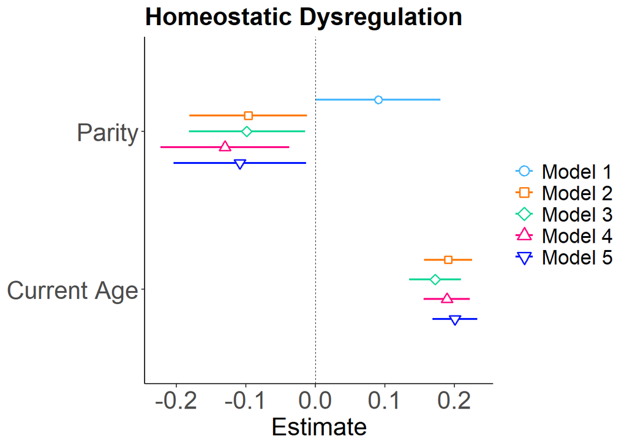

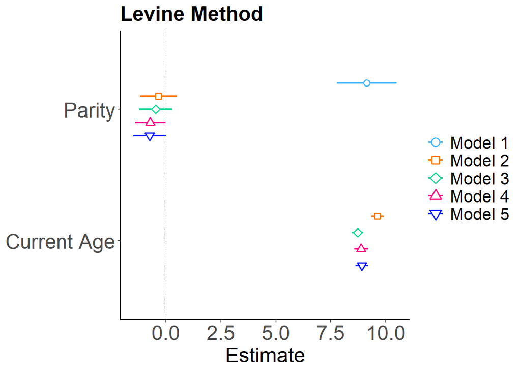

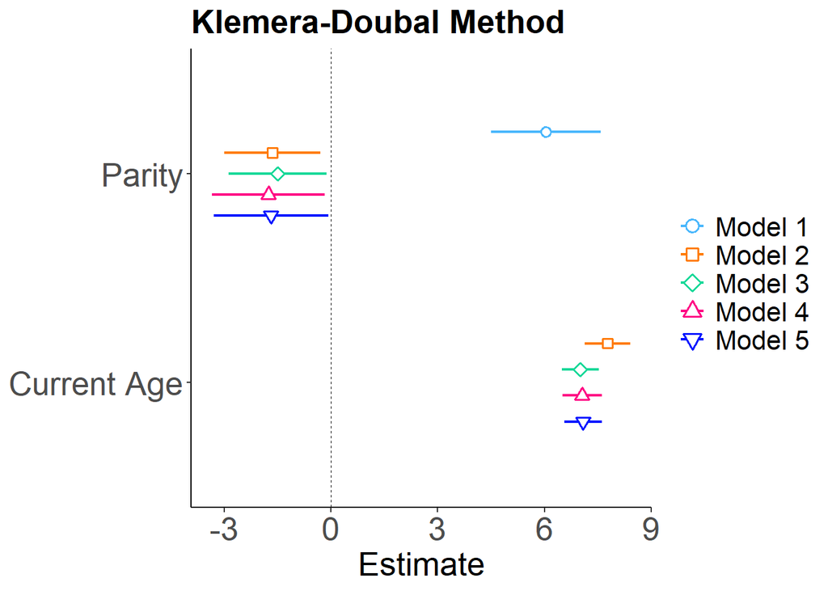

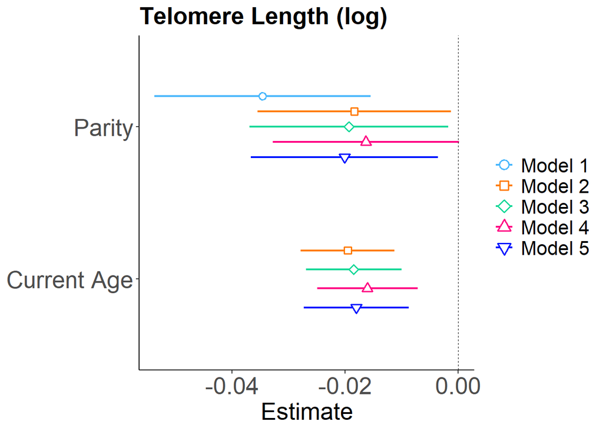

And for those of us who hate figures, here’s a table for models which include age, BMI, smoking status, ethnicity, and the the composite of ‘resource availibility’ as covariates (and obviously, whether a woman has ever been pregnant).

|  | HD | LM | KDM | log_telo |
| --- | --- | --- | --- | --- |
|  | (1) | (2) | (3) | (4) |
| everpreg | -0.051 | -0.552 | -1.500 | -0.029** |
| Dim.1 | -0.003 | 0.469 | -0.066 | 0.009 |
| age | 0.023** | 1.008** | 0.802** | -0.002** |
| bmi | 0.019** | 0.281** | 0.375** | -0.001** |
| smoking | 0.033 | 0.750** | 0.231 | -0.002 |
| ridreth1 | 0.023 | 0.024 | 0.117 | 0.004 |
| everpreg:Dim.1 | 0.073<sup>+</sup> | 0.250 | 0.243 | -0.012<sup>+</sup> |
| Constant | 1.728** | -16.266** | -2.058* | 0.174** |
| Observations | 1,608 | 1,647 | 1,663 | 1,484 |
| Log Likelihood | -1,653.576 | -5,259.686 | -5,478.799 | 1,137.005 |
| Akaike Inf. Crit. | 3,323.152 | 10,535.370 | 10,973.600 | -2,258.009 |
| *Note:* | +p<0.1;*p<0.05;**p<0.01;***p<0.001 |  |  |  |

Not analysis-based but potentially informative: here’s a correlation matrix (values represent r values) for many variables of interest analyzed above.

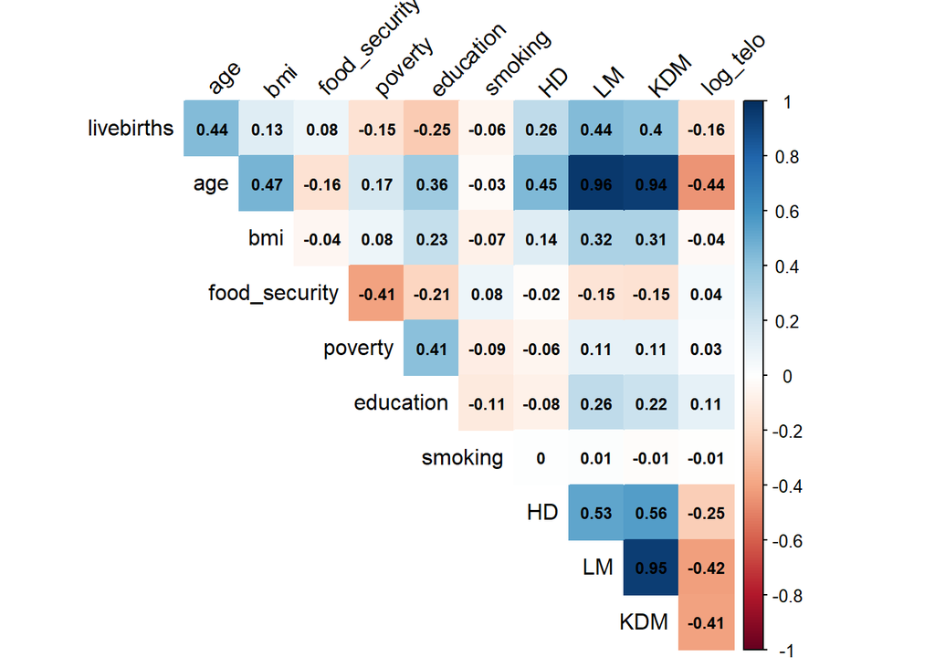

Let’s look at a correlation matrix for just the biological aging measures.

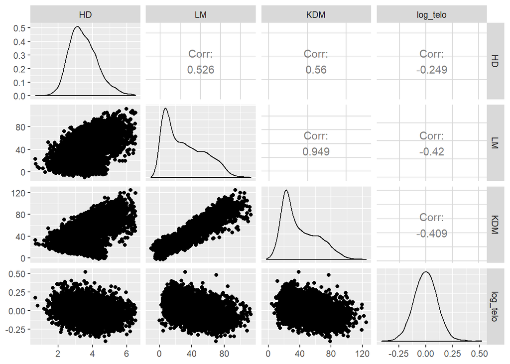